# Artificial Neural Networks & Deep Learning

Mattia Barbero - David Cardoner - Arnau Mercader

# Introducción

## Descripción de los datos

En esta práctica la idea es aprender a usar distintas combinaciones de redes neuronales (NN) y redes profundas (en concreto CNN) para intentar clasificar imágenes en distintas categorías. El conjunto de datos que se usará se puede obtener a través del siguiente enlace:

http://www.vision.caltech.edu/Image_Datasets/Caltech101/

## Paquetes necesarios

El siguiente código permite cargar e instalar, si es necesario, las librerías necesarias para ejecutar todo el código restante.

```r
options(width = 10e2)
# install needed packages
# for using keras, firstly install Anaconda software
list.of.packages <- c("readr","plyr","dplyr","ggplot2","rmarkdown","knitr",
                      'tidyr','keras','OpenImageR')
new.packages <- list.of.packages[!(list.of.packages %in% installed.packages()[,"Package"])]
if(length(new.packages)) install.packages(new.packages)
invisible(suppressWarnings(suppressMessages(lapply(list.of.packages, require,character.only = TRUE))))
list.of.packages <- NULL
```

Se carga un Rdata para agilizar el output del documento markdown:

```r
load('load0.Rdata')
```

# Arquitectura NN

A continuación se usarán dos metodologías, descriptores HOG y modificación de la medida de la imágen para entrenar distintas estructuras de redes e intentar definir las más precisas. Como output del modelo se deben escoger 5 categorías de imágenes. A continuación se muestra código R para poder leer las imágenes de forma correcta.

## Lectura de imágenes

Para que la red pueda aprender más, se escogerán aquellas categorías que tengan un número de imágenes elevado. Para saber esto, analizemos los directorios donde se encuentran las imágenes. Para usar el siguiente código se supone que tenemos los datos de las imágenes descomprimidos en nuestro directorio de trabajo.

## Definición de directorio de las imágenes

Por tal de ver que categorías escoger, veamos un poco la distribución de nuestras imágenes usando principalmente la función *list.files* de R.

```r
categories <- list.files("101_ObjectCategories/101_ObjectCategories/")
n_files <- list(length(categories))

for (i in 1:length(categories)) {

n_files[[i]] <- length(list.files(paste0("101_ObjectCategories/101_ObjectCategories/",categories[i]),
                           pattern = ".jpg"))
}

plot(unlist(n_files),col='steelblue',xlim=c(0,102),ylab='Files count',main = 'Freq. of categories')
idx0 <- which(unlist(n_files) > 200)
i<- NULL
```

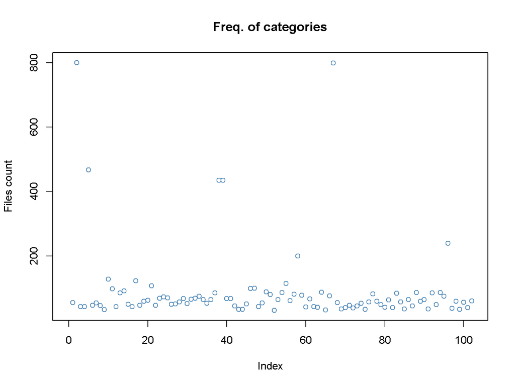

```r
plot(unlist(n_files),col='steelblue',xlim=c(0,102),ylab='Files count',main = 'Freq. of categories')
```

Si analizamos el anterior gráfico, vemos que solo 6 categorías superan un conteo de más de 200 imágenes de estas escogeremos 5. A comentar que el vector de directorios tiene medida 102, por lo tanto las categorías parece que son 102 y no 101 (quizás porque las categorías face y face easy se cuentan como una). En la siguiente tabla se resumen las categorías mencionadas anteriormente:

```r
kable(data.frame(category = categories[idx0],
                 freq=unlist(n_files)[idx0]))
```

| category | freq |
| --- | --- |
| airplanes | 800 |
| BACKGROUND_Google | 467 |
| Faces | 435 |
| Faces_easy | 435 |
| Motorbikes | 798 |
| watch | 239 |

## Enfoque HOG

Para esta primera metodología o enfoque usaremos 2 combinaciones de NN, que se detallan a continuación:

Para el HOG se usarán 3 celdas y 9 orientaciones lo que dará lugar a 81 columnas (de aquí 81 unidades en la capa de input).

A continuación se crea un bucle para leer las imágenes seleccionadas y construir los descriptores. Las 5 categorías escogidas son: **Faces, airplanes, BACKGROUND_Google, Motorbikes y watch**. Para balancear las distintas categorías se escogerá de cada categoría el mínimo global, que es 239.

```r
path = "101_ObjectCategories/101_ObjectCategories/Faces/"
path2 = "101_ObjectCategories/101_ObjectCategories/airplanes/"
path3  = "101_ObjectCategories/101_ObjectCategories/BACKGROUND_Google/"
path4 = "101_ObjectCategories/101_ObjectCategories/Motorbikes/"
path5 = "101_ObjectCategories/101_ObjectCategories/watch/"


ii<-list.files("101_ObjectCategories/101_ObjectCategories/Faces",pattern = ".jpg")
j<-list.files("101_ObjectCategories/101_ObjectCategories/airplanes",pattern = ".jpg")
k<-list.files("101_ObjectCategories/101_ObjectCategories/BACKGROUND_Google",pattern = ".jpg")
l<-list.files("101_ObjectCategories/101_ObjectCategories/Motorbikes",pattern = ".jpg")
m<-list.files("101_ObjectCategories/101_ObjectCategories/watch",pattern = ".jpg")
minim = min(length(ii),length(j),length(k),length(l),length(m))

combof = matrix(nrow=minim,ncol=81)
combof2 = matrix(nrow=minim,ncol=81)
combof3 = matrix(nrow=minim,ncol=81)
combof4 = matrix(nrow=minim,ncol=81)
combof5 = matrix(nrow=minim,ncol=81)

for (i in 1:minim){

 # reading images
image = readImage(paste0(path,ii[i]))
image2 = readImage(paste0(path2,j[i]))
image3 = readImage(paste0(path3,k[i]))
image4 = readImage(paste0(path4,l[i]))
image5 = readImage(paste0(path5,m[i]))

# resize value of image
image = image * 255
image2 = image2 * 255
image3 = image3 * 255
image4 = image4 * 255
image5 = image5 * 255

# perform descriptor
hog =  HOG(image, cells = 3, orientations = 9)
hog2 = HOG(image2, cells = 3, orientations = 9)
hog3 = HOG(image3, cells = 3, orientations = 9)
hog4 = HOG(image4, cells = 3, orientations = 9)
hog5 = HOG(image5, cells = 3, orientations = 9)

# assign to matrix
combof[i,] = hog
combof2[i,] = hog2
combof3[i,] = hog3
combof4[i,] = hog4
combof5[i,] = hog5
}
```

A continuación creamos nuestra variable respuesta y juntamos la información con nuestros descriptores. Obtenemos como resultado un objeto con 1195 filas (239 por 5 categorías), y 82 columnas (81 de los descriptores más la variable respuesta categorizada numéricamente como 0,1,2,3 y 4).

```r
resp <- rep(c(0,1,2,3,4),each=minim)
dataimage = data.frame(rbind(combof,combof2,combof3,combof4,combof5))
dataimage = cbind(dataimage,resp)
```

A continuación permutamos nuestros datos y separamos nuestro conjunto en 2 partes: train (70%) y test (30%).

```r
# permut data
set.seed(123)
idx_permut <- sample(c(1:nrow(dataimage),size=nrow(dataimage)))
dataimage <- dataimage[idx_permut,]

# train / test  (.7 / .3)
resp_cat  = to_categorical(dataimage[,"resp"],num_classes=5)

set.seed(1000)
p <- 0.7
idx <- sample(x = 1:nrow(dataimage),size = p*nrow(dataimage))


train_y = resp_cat[idx,]
train_x = dataimage[idx,-82] %>% as.matrix()

test_y = resp_cat[-idx,]
test_x = dataimage[-idx,-82] %>% as.matrix()
```

### Primer enfoque HOG

Como se ha comentado antes, como primer enfoque usaremos la siguiente configuración.

- Layer 1: 81 units (input layer), Layer 2: 10 units (hidden layer), Layer 3: 5 units (output layer).
- Como función de activación se usará la función sigmoidal
- Como métrica de ajuste se usa *Accuracy*
- Repeticiones usadas (ephocs) = 100
- Muestras para actualizar el gradiente = 32
- Porcentaje de train para validación = 25%
- Función de activación output = softmax

```r
a <- Sys.time()
# KERAS APPROACH
model <- keras_model_sequential()
# CONF 1. (1 hidden)
model %>%
layer_dense(units = 10, activation = 'sigmoid', input_shape = c(81)) %>%
#layer_dropout(rate = 0.1) %>%
#layer_batch_normalization() %>%
layer_dense(units = 5, activation = "softmax")

model %>% compile(
  loss = "categorical_crossentropy",
  # (lr = 0.05, decay = 0.001)
  #optimizer = optimizer_rmsprop(),
  optimizer = "rmsprop",
  metrics = c("accuracy")
)

model %>% compile(
  loss = "categorical_crossentropy",
  # (lr = 0.05, decay = 0.001)
  #optimizer = optimizer_rmsprop(),
  optimizer = "rmsprop",
  metrics = c("accuracy")
)

set.seed(10)
history <- model %>% fit(
  train_x, train_y,
  # epohcs repeticions per train model
  # batch_size mostre per actualizar gradient update
  epochs = 100, batch_size = 32,
  validation_split = 0.25,
  callbacks = list(
    callback_early_stopping(patience=10)

  )
)

Sys.time() -a
```

```
Time difference of 10.1833 secs
```

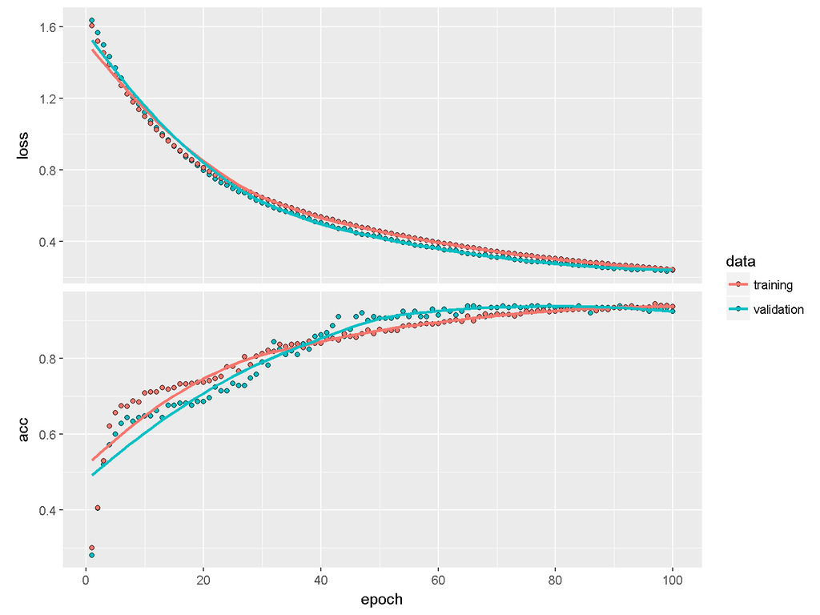

```r
plot(history)
```

```r
model %>% evaluate(test_x,test_y)
```

```
$loss
[1] 0.3485862

$acc
[1] 0.8802228
```

```r
pred_test <- model %>% predict_classes(test_x) %>% as.vector()
table(pred_test,dataimage[-idx,"resp"])
```

```
pred_test  0  1  2  3  4
        0 55  0 12  0  2
        1  1 74  1  1  1
        2  5  2 49  0  9
        3  0  1  2 66  1
        4  0  1  4  0 72
```

Parece que la red se ajusta bien y se obtienen buenos resultados. Usemos ahora una función intermedia (dropout = 0.1) y como función de activación la rectificador (más conocida como relu), para ver si incrementemos un poco el crecimiento de exactitud.

```r
a <- Sys.time()
# KERAS APPROACH 2
model <- keras_model_sequential()
# CONF 1.1. (1 hidden)
model %>%
layer_dense(units = 10, activation = 'relu', input_shape = c(81)) %>%
layer_dropout(rate = 0.1) %>%
layer_dense(units = 5, activation = "softmax")

model %>% compile(
  loss = "categorical_crossentropy",
  # (lr = 0.05, decay = 0.001)
  #optimizer = optimizer_rmsprop(),
  optimizer = "rmsprop",
  metrics = c("accuracy")
)

model %>% compile(
  loss = "categorical_crossentropy",
  # (lr = 0.05, decay = 0.001)
  #optimizer = optimizer_rmsprop(),
  optimizer = "rmsprop",
  metrics = c("accuracy")
)
set.seed(10)
history <- model %>% fit(
  train_x, train_y,
  # epohcs repeticions per train model
  # batch_size mostre per actualizar gradient update
  epochs = 100, batch_size = 32,
  validation_split = 0.25,
  callbacks = list(
    callback_early_stopping(patience=10)


  )
)

Sys.time() - a
```

```
Time difference of 6.067271 secs
```

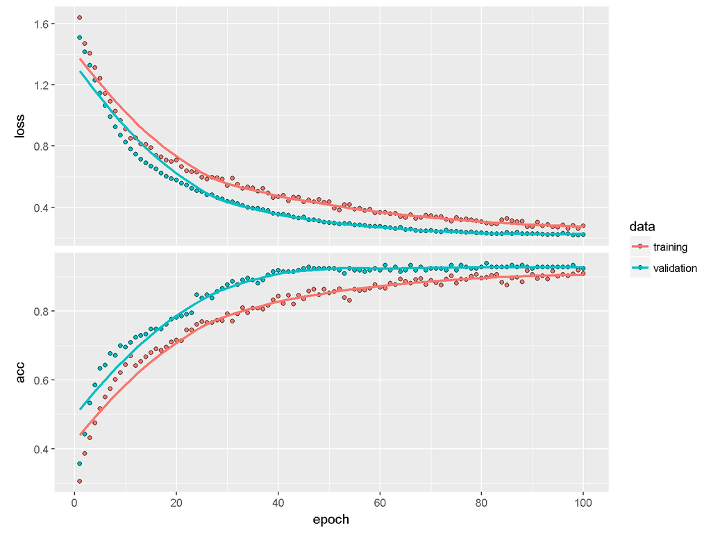

```r
plot(history)
```

```r
model %>% evaluate(test_x,test_y)
```

```
$loss
[1] 0.306964

$acc
[1] 0.8941504
```

```r
pred_test <- model %>% predict_classes(test_x) %>% as.vector()
table(pred_test,dataimage[-idx,"resp"])
```

```
pred_test  0  1  2  3  4
        0 58  0  7  0  0
        1  2 76  3  2  1
        2  1  1 49  0 11
        3  0  1  3 65  0
        4  0  0  6  0 73
```

### Segundo enfoque HOG

Como se ha comentado antes, usemos ahora el siguiente enfoque:

- Layer 1: 81 units (input layer), Layer 2: 40 units (hidden layer), Layer 3: 20 units (hidden layer), Layer 4: 5 units (output layer).
- Como función de activación se usará la función sigmoidal y relu
- Como métrica de ajuste se usa *Accuracy*
- Repeticiones usadas (ephocs) = 100
- Muestras para actualizar el gradiente = 32
- Porcentaje de train para validación = 25%
- Función de activación output = softmax

```r
a <- Sys.time()
# KERAS APPROACH
model <- keras_model_sequential()
# CONF 2. ( 2 hidden 40 / 20 )

model %>%

layer_dense(units = 40, activation = 'sigmoid', input_shape = c(81)) %>%
layer_dense(units = 20, activation = "relu") %>%
layer_dense(units = 5, activation = "softmax")


model %>% compile(
  loss = "categorical_crossentropy",
  # (lr = 0.05, decay = 0.001)
  #optimizer = optimizer_rmsprop(),
  optimizer = "rmsprop",
  metrics = c("accuracy")
)

model %>% compile(
  loss = "categorical_crossentropy",
  # (lr = 0.05, decay = 0.001)
  #optimizer = optimizer_rmsprop(),
  optimizer = "rmsprop",
  metrics = c("accuracy")
)
set.seed(10)
history <- model %>% fit(
  train_x, train_y,
  # epohcs repeticions per train model
  # batch_size mostre per actualizar gradient update
  epochs = 100, batch_size = 32,
  validation_split = 0.25,
  callbacks = list(
    callback_early_stopping(patience=10)
    # callback_reduce_lr_on_plateau(patience=5)
  )
)

Sys.time() - a
```

```
Time difference of 5.825745 secs
```

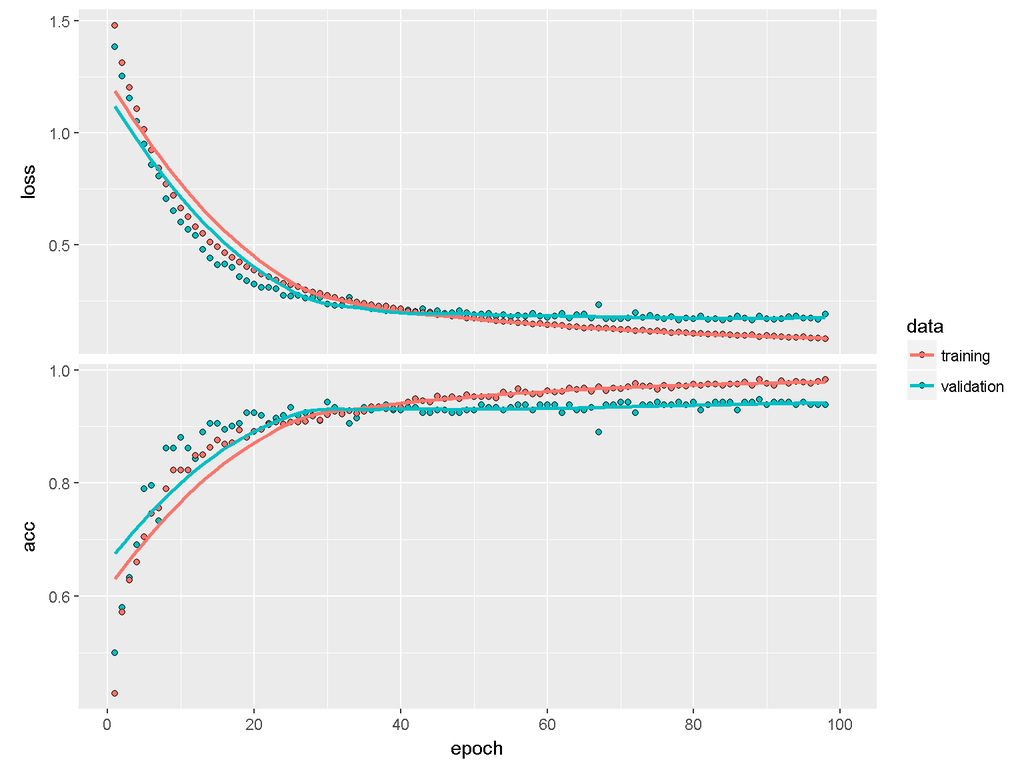

```r
plot(history)
```

```r
model %>% evaluate(test_x,test_y)
```

```
$loss
[1] 0.3888188

$acc
[1] 0.8802228
```

```r
pred_test <- model %>% predict_classes(test_x) %>% as.vector()
table(pred_test,dataimage[-idx,"resp"])
```

```
pred_test  0  1  2  3  4
        0 58  0 18  0  3
        1  1 77  1  1  2
        2  2  1 41  0  6
        3  0  0  2 66  0
        4  0  0  6  0 74
```

Parece que esta configuración converge bastante bien, usemos ahora una configuración con 2 capas internas pero con menos inputs y mantegamos la segunda función de activación en relu.

- Layer 1: 81 units (input layer), Layer 2: 25 units (hidden layer), Layer 3: 10 units (hidden layer with relu activation), Layer 4: 5 units (output layer).

```r
a <- Sys.time()
# KERAS APPROACH
model <- keras_model_sequential()
# CONF 2.1 ( 2 hidden 25 / 10 )

model %>%

layer_dense(units = 25, activation = 'sigmoid', input_shape = c(81)) %>%
#layer_dropout(rate = 0.3) %>%
layer_dense(units = 10, activation = "relu") %>%
layer_dense(units = 5, activation = "softmax")


model %>% compile(
  loss = "categorical_crossentropy",
  # (lr = 0.05, decay = 0.001)
  #optimizer = optimizer_rmsprop(),
  optimizer = "rmsprop",
  metrics = c("accuracy")
)

model %>% compile(
  loss = "categorical_crossentropy",
  # (lr = 0.05, decay = 0.001)
  #optimizer = optimizer_rmsprop(),
  optimizer = "rmsprop",
  metrics = c("accuracy")
)

set.seed(10)
history <- model %>% fit(
  train_x, train_y,
  # epohcs repeticions per train model
  # batch_size mostre per actualizar gradient update
  epochs = 100, batch_size = 32,
  validation_split = 0.25,
  callbacks = list(
    callback_early_stopping(patience=10)
    # callback_reduce_lr_on_plateau(patience=5)
  )
)

Sys.time() -a
```

```
Time difference of 5.625139 secs
```

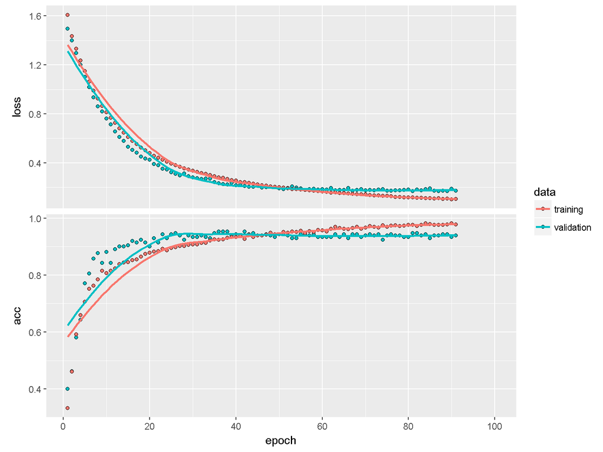

```r
plot(history)
```

```r
model %>% evaluate(test_x,test_y)
```

```
$loss
[1] 0.3253679

$acc
[1] 0.8885794
```

```r
pred_test <- model %>% predict_classes(test_x) %>% as.vector()
table(pred_test,dataimage[-idx,"resp"])
```

```
pred_test  0  1  2  3  4
        0 56  0 10  0  2
        1  1 74  2  1  1
        2  4  2 47  0  6
        3  0  2  2 66  0
        4  0  0  7  0 76
```

## Enfoque modificación medida imagen (resize style)

En este apartado, se usará otra metodología que consiste en trabajar directamente con las imágenes como inputs. En nuestro caso, se ajustará la dimensión de todas las imágenes a 32x32 píxels. El tercer elemento representa la textura de la imagen. Con este proceso, la imágen pierde calidad pero a la vez ganamos en que cada categoría tendrá un patrón más homogeneo, y es con estos patrones con los que nuestra red clasificará. Como antes, se usarán las mismas 5 categorías. Se deben vectorizar las imágenes, por lo que obtendremos inputs con 1024 filas (32x32).

Algunas fotos de la categoría BACKGROUND_Google no son RGB, por lo que condicionamos el bucle por si en alguna iteración encuentra una imagen que no sea en formato RGB, no use la función rgb_2gray (función que pasa una imagen RGB a escala de grises). A continuación se detalla el proceso para preparar los inputs. Para acelerar el markdown, se carga un Rdata, como ya se ha hecho antes en la creación de los descriptores HOG.

```r
load("load1.Rdata")
```

```r
path = "101_ObjectCategories/101_ObjectCategories/Faces/"
path2 = "101_ObjectCategories/101_ObjectCategories/airplanes/"
path3  = "101_ObjectCategories/101_ObjectCategories/BACKGROUND_Google/"
path4 = "101_ObjectCategories/101_ObjectCategories/Motorbikes/"
path5 = "101_ObjectCategories/101_ObjectCategories/watch/"


ii<-list.files("101_ObjectCategories/101_ObjectCategories/Faces",pattern = ".jpg")
j<-list.files("101_ObjectCategories/101_ObjectCategories/airplanes",pattern = ".jpg")
k<-list.files("101_ObjectCategories/101_ObjectCategories/BACKGROUND_Google",pattern = ".jpg")
l<-list.files("101_ObjectCategories/101_ObjectCategories/Motorbikes",pattern = ".jpg")
m<-list.files("101_ObjectCategories/101_ObjectCategories/watch",pattern = ".jpg")
minim = min(length(ii),length(j),length(k),length(l),length(m))


greyof = matrix(nrow=minim,ncol=1024)
greyof2 = matrix(nrow=minim,ncol=1024)
greyof3 = matrix(nrow=minim,ncol=1024)
greyof4 = matrix(nrow=minim,ncol=1024)
greyof5 = matrix(nrow=minim,ncol=1024)


for (i in 1:minim){
  #print(i)
  # reading images

  image =  rgb_2gray(readImage(paste0(path,ii[i])))
  image2 = rgb_2gray(readImage(paste0(path2,j[i])))
  image3= readImage(paste0(path3,k[i]))

  if(length(dim(image3))<3){
  image3 = image3;
  } else {image3 = rgb_2gray(image3);}

  image4 = rgb_2gray(readImage(paste0(path4,l[i])))
  image5 = rgb_2gray(readImage(paste0(path5,m[i])))



  small.img = resizeImage(image, width = 32, height = 32, method = 'bilinear')
  small.img2 = resizeImage(image2, width = 32, height = 32, method = 'bilinear')
  small.img3 = resizeImage(image3, width = 32, height = 32, method = 'bilinear')
  small.img4 = resizeImage(image4, width = 32, height = 32, method = 'bilinear')
  small.img5 = resizeImage(image5, width = 32, height = 32, method = 'bilinear')


  greyof[i,] =  small.img
  greyof2[i,] = small.img2
  greyof3[i,] = small.img3
  greyof4[i,] = small.img4
  greyof5[i,] = small.img5

}


resp <- rep(c(0,1,2,3,4),each=minim)
dataimage = data.frame(rbind(greyof,greyof2,greyof3,greyof4,greyof5))
dataimage = cbind(dataimage,resp)


# permut data
set.seed(123)
idx_permut <- sample(c(1:nrow(dataimage),size=nrow(dataimage)))
dataimage <- dataimage[idx_permut,]

# train / test  (.7 / .3)
resp_cat  = to_categorical(dataimage[,"resp"])

set.seed(1000)
p <- 0.7
idx <- sample(x = 1:nrow(dataimage),size = p*nrow(dataimage))



train_y = resp_cat[idx,]
train_x = dataimage[idx,-1025] %>% as.matrix()

test_y = resp_cat[-idx,]
test_x = dataimage[-idx,-1025] %>% as.matrix()
```

Después de distintas configuraciones, a continuación se detallan 2 para ver su comportamiento y se grafica su performance así como el tiempo CPU. A comentar, cuando ejecutamos el código markdown las funciones keras se usan en formato binario por lo que este tiempo es mucho más rápido que correr Keras en Rstudio, cosa que es realmente muy útil. Estas configuraciones no requieren de mucho tiempo CPU, pero si nuestros inputs fueran muy grandes, quizás ejecutar código vía ejecución markdown nos permite agilizar nuestra implementación.

### Primera configuración

```r
a <- Sys.time()
model <- keras_model_sequential()
# model %>%
#   layer_dense(units = 50, activation = "sigmoid", input_shape = ncol(train_x)) %>%
#   #layer_dropout(rate = 0.2) %>%
#   #layer_dense(units = 30, activation = "sigmoid") %>%
#   #layer_dropout(rate = 0.1) %>%
#   layer_dense(units = 10, activation = "sigmoid") %>%
#   layer_dense(units = 2, activation = "relu") %>%
#    layer_dense(units = 5, activation = "softmax")

model %>%
  layer_dense(units = 60, activation = "sigmoid", input_shape = ncol(train_x)) %>%
  layer_dropout(rate = 0.4) %>%
  layer_dense(units = 10, activation = "relu") %>%
  layer_dense(units = 5, activation = "softmax")


model %>% compile(
  loss = "categorical_crossentropy",
  optimizer = "rmsprop",
  metrics = c("accuracy")
)

history <- model %>% fit(
  train_x, train_y,
  epochs = 100, batch_size = 32,
  validation_split = 0.25
)

Sys.time() -a
```

```
Time difference of 9.643015 secs
```

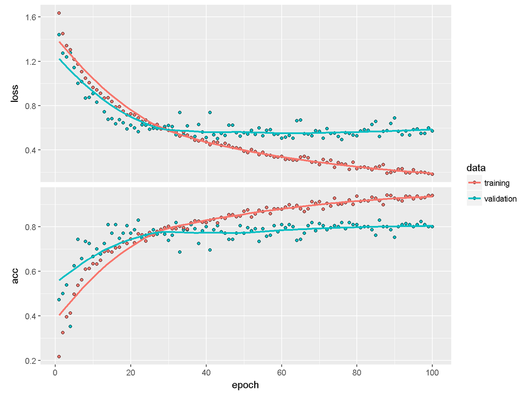

```r
plot(history)
```

```r
model %>% evaluate(test_x,test_y)
```

```
$loss
[1] 0.7287867

$acc
[1] 0.7493036
```

```r
pred_test <- model %>% predict_classes(test_x) %>% as.vector()
table(pred_test,dataimage[-idx,"resp"])
```

```
pred_test  0  1  2  3  4
        0 51  0  9  0  2
        1  0 67 11  7  7
        2  6  8 38  3 20
        3  1  1  0 57  0
        4  3  2 10  0 56
```

### Segunda configuración

A continuación, en comparación a la anterior configuración, en esta se considera un tamaño batch superior, se reducen a 40 las unidades de la capa inicial e se incrementa la segunda capa a 20 unidades. Por lo que hace a las funciones de activación, se invierten.

```r
a <- Sys.time()
model <- keras_model_sequential()

model %>%
  layer_dense(units = 40, activation = "relu", input_shape = ncol(train_x)) %>%
  layer_dropout(rate = 0.4) %>%
  layer_dense(units = 20, activation = "sigmoid") %>%
  layer_dense(units = 5, activation = "softmax")


model %>% compile(
  loss = "categorical_crossentropy",
  optimizer = "rmsprop",
  metrics = c("accuracy")
)

set.seed(10)
history <- model %>% fit(
  train_x, train_y,
  epochs = 100, batch_size = 80,
  validation_split = 0.25
)

Sys.time() - a
```

```
Time difference of 5.208134 secs
```

```r
plot(history)
```

[output not shown]

```r
model %>% evaluate(test_x,test_y)
```

```
$loss
[1] 0.5643964

$acc
[1] 0.7771588
```

```r
pred_test <- model %>% predict_classes(test_x) %>% as.vector()
table(pred_test,dataimage[-idx,"resp"])
```

```
pred_test  0  1  2  3  4
        0 50  0  6  0  2
        1  1 65  3  6  2
        2  8  6 37  1 13
        3  0  1  0 59  0
        4  2  6 22  1 68
```

Con esta estructura, parece que nuestra validación se bloquea alrededor de 0.7/0.8 (con algunas configuraciones se ha obtenido 0.8 en el test, pero no se acaba de encontrar un algoritmo equilibrado). Por lo que podemos concluir que los descriptores HOG dan mejores resultados.

# Arquitectura CNN

En este último apartado, se considerarán redes convolucionales, estas se usan normalmente en problemas de visión artificial, como en nuestro caso clasificación de imágenes ya que se trabaja con matrices bidimensionales. Nuestros inputs serán imágenes en escala de grises, tal y como hemos trabajado en las configuraciones anteriores pero en este caso no vectorizamos nuestros inputs, formamos arrays, en este caso 32x32x1 e iremos retroalimentando nuestra red. El incoveniente de estas redes, es que su aprendizaje es más lento en comparación a las anteriores configuraciones estudiadas en este documento. A continuación se detallan 2 configuraciones y se dan los outputs respectivos.

## Primer enfoque

A continuación, se construyen los inputs y la matriz de respuestas para las 3 categorías y se usa la función array_reshape para obtener las matrices bidimensionales.

```r
a <- Sys.time()
resp <- rep(c(0,1,2),each=minim)
dataimage2 = data.frame(rbind(greyof,greyof2,greyof4))
dataimage2 = cbind(dataimage2,resp)
# permut data
set.seed(123)
idx_permut <- sample(c(1:nrow(dataimage2),size=nrow(dataimage2)))
dataimage2 <- dataimage2[idx_permut,]

# train / test  (.5 / .5)
resp_cat  = to_categorical(dataimage2[,"resp"])

set.seed(1000)
p <- 0.5
idx <- sample(x = 1:nrow(dataimage2),size = p*nrow(dataimage2))

train_y = resp_cat[idx,]
train_x = dataimage2[idx,-1025] %>% as.matrix()

test_y = resp_cat[-idx,]
test_x = dataimage2[-idx,-1025] %>% as.matrix()


train_x <- array_reshape(train_x, c(nrow(train_x), 32, 32, 1))
test_x <- array_reshape(test_x, c(nrow(test_x), 32,32, 1))

model <- keras_model_sequential() %>%
  layer_conv_2d(filters = 20, kernel_size = c(3,3), activation = 'relu',
                input_shape = c(32,32,1)) %>%
  #layer_conv_2d(filters = 64, kernel_size = c(3,3), activation = 'relu') %>%
  layer_max_pooling_2d(pool_size = c(2, 2)) %>%
  #layer_dropout(rate = 0.2) %>%
  layer_flatten() %>%
  layer_dense(units = 128, activation = 'relu') %>%
  #layer_dropout(rate = 0.2) %>%
  layer_dense(units = 3, activation = 'softmax')

# Print a summary of a model
#summary(model)

# Compile model
model %>% compile(
  loss = loss_categorical_crossentropy,
  optimizer = optimizer_adadelta(),
  metrics = c('accuracy')
)

set.seed(10)
# Train model
model %>% fit(
  train_x, train_y,
  batch_size = 50,
  epochs = 100,
  validation_split = 0.25
)

Sys.time() - a
```

```
Time difference of 38.16203 secs
```

```r
plot(history)
```

[output not shown]

```r
model %>% evaluate(test_x,test_y)
```

```
$loss
[1] 0.05090923

$acc
[1] 0.9805014
```

```r
pred_test <- model %>% predict_classes(test_x) %>% as.vector()
table(pred_test,dataimage2[-idx,"resp"])
```

```
pred_test   0   1   2
        0 118   2   0
        1   1 117   2
        2   0   2 117
```

## Segundo enfoque

A continuación, se detalla la configuración de otra estructura CNN.

```r
model <- keras_model_sequential() %>%
  layer_conv_2d(filters = 32, kernel_size = c(3,3), activation = 'relu',
                input_shape = c(32,32,1)) %>%
  layer_conv_2d(filters = 64, kernel_size = c(3,3), activation = 'relu') %>%
  layer_max_pooling_2d(pool_size = c(2, 2)) %>%
  layer_dropout(rate = 0.2) %>%
  layer_flatten() %>%
  layer_dense(units = 128, activation = 'relu') %>%
  layer_dropout(rate = 0.2) %>%
  layer_dense(units = 3, activation = 'softmax')

# Print a summary of a model
#summary(model)
```

Por lo que hace a características del algoritmo:

```r
a <- Sys.time()

# Compile model
model %>% compile(
  loss = loss_categorical_crossentropy,
  optimizer = optimizer_adadelta(),
  metrics = c('accuracy')
)

# Train model
model %>% fit(
  train_x, train_y,
  batch_size = 50,
  epochs = 100,
  validation_split = 0.25
)

Sys.time() -a
```

```
Time difference of 3.993005 mins
```

```r
plot(history)
```

[output not shown]

```r
model %>% evaluate(test_x,test_y)
```

```
$loss
[1] 0.08033768

$acc
[1] 0.9721448
```

```r
pred_test <- model %>% predict_classes(test_x) %>% as.vector()
table(pred_test,dataimage2[-idx,"resp"])
```

```
pred_test   0   1   2
        0 118   4   0
        1   1 117   5
        2   0   0 114
```

# Conclusiones